# ERGM Analysis on the Elite-Think Tank Network of the United States

Jae Hyoung Choi (word count: 773)

23 December 2021

# 1. Introduction

```r
USA_elite_advice_v3 <- read_xlsx("USA_elite_advice v3.xlsx")
elite_attr <- USA_elite_advice_v3[,1:4]
elite_mat <- as.matrix(USA_elite_advice_v3[,-(1:5)])
row.names(elite_mat) = USA_elite_advice_v3$name
```

In attempt to find what drives the connection among the US elites, I will analyse `mpn_elite_usa_advice`, a two-mode network based on Domhoff’s (2016) US elite database (Hollway 2021). The network visualises the connection between 14 US elites to 20 US think tanks. Though not exhaustive, it serves as a good representation of the relationship between the US elites and influential US think tanks.

However, I took the liberty of modifying the dataset to partly remedy its skewness towards male and conservative figures. This skewness may affect our analysis and interpretation. Therefore, partly based on *Forbes*’ World’s 100 Most Powerful Women, I added four more figures and two more think tanks in the dataset. Hopefully, the additions, though insufficient, have slightly balanced the attribute distributions.

# 2. Network Visualisation

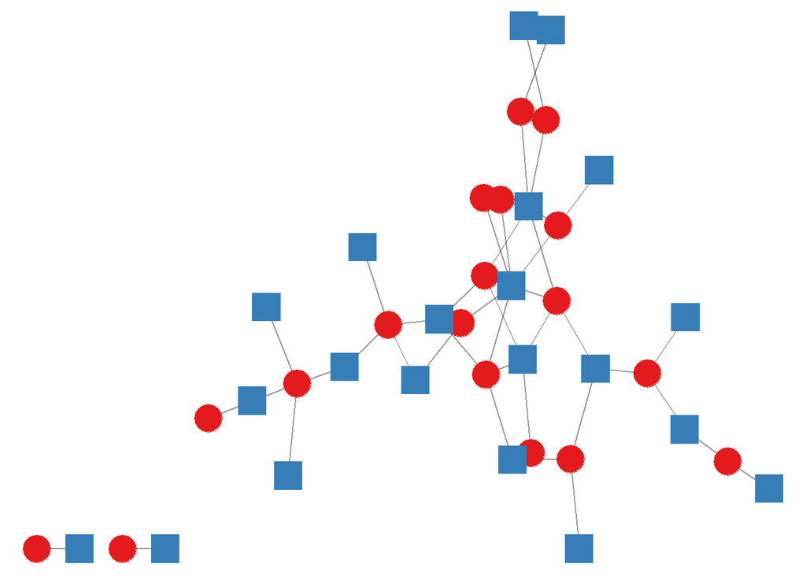

```r
autographr(elite_mat, labels = FALSE,
           node_color = "type", node_size = 8)
```

# 3. Notes on Attributes

I attached three attributes to the elites:

```r
Party_aff <- as.numeric(as.character(elite_attr$Party_affiliation))
Gender <- as.numeric(as.character(elite_attr$Gender))
Primary_occ <- as.numeric(as.character(elite_attr$Primary_occupation))
elite_mat <- network(elite_mat, undirected=T, bipartite=18)
elite_mat %v% "Gender" <- c(Gender, rep(NA,22))
elite_mat %v% "Party Affiliation" <- c(Party_aff, rep(NA,22))
elite_mat %v% "Primary Occupation" <- c(Primary_occ, rep(NA,22))
```

1. **Gender = {Female (0), Male (1)}** Female elites and male elites may have different patterns of behaviour in the male-dominant US establishment.
2. **Party affiliation = {Democrat (1), Republican (2), none (0)}** Party affiliation serves as a reliable proxy variable for each person’s political leanings and relationship with the vested interests in US society.
3. **Primary occupation = {Bureaucrat (1), Entrepreneur (2), Academic (3), Lawyer (4), Military (5)}** For example, successful businessmen are more exposed to encounters with politicians and other entrepreneurs than with academics. The following table is the list of attributes assigned to each person.

```r
elite_attr
```

```
## # A tibble: 18 x 4
##    name                      Primary_occupation Gender Party_affiliation
##    <chr>                                  <dbl>  <dbl>             <dbl>
##  1 Albright, Madeleine K.                     1      0                 1
##  2 Argyros, George L.                         2      1                 2
##  3 Armitage, Richard L.                       1      1                 2
##  4 Curry, Ravenel Boykin III                  2      1                 0
##  5 Fukuyama, Francis                          3      1                 0
##  6 Gray, C. Boyden                            4      1                 2
##  7 Greenberg, Maurice R.                      2      1                 2
##  8 Hills, Carla A.                            1      0                 2
##  9 Kissinger, Henry                           3      1                 2
## 10 Peterson, Peter G.                         2      1                 2
## 11 Scowcroft, Brent                           5      1                 2
## 12 Wald, Charles F.                           5      1                 0
## 13 West, J. Robinson                          2      1                 0
## 14 Zakheim, Dov S.                            1      1                 2
## 15 Nooyi, Indra                               2      0                 0
## 16 Clinton, Hilary                            1      0                 1
## 17 Gore, Al                                   1      1                 1
## 18 Sandberg, Shery                            2      0                 0
```

# 4. Model Specification

The goal is to measure the magnitudes of the effects on the probability of tie formation $E[X_{ij}]$ = $P(X_{ij} = 1)$ in the network by running an ERGM (Amati, Lomi, and Mira 2018, 351). As other ERGMs, we assume parameter homogeneity, equating the parameters of the isomorphic local configurations.

The network effects derive from the two-mode nature of the network. The first dependence is independence among tie variables, expressed by the number of ties (`edges`). Markov dependence is captured by alternating *k*-stars with the persons at the centre (`gwb1degree`) and with the institutes at the centre (`gwb2degree`). They also help prevent a phase transition into degeneracy (Wang 2013, 122-23). In order to model clustering effects beyond the Markov assumption, we employ alternating cycles for social circuits, `gwb1dsp` and `gwb2dsp`. For all the geometrically weighted variables, the usual decay rate of 0.25 is adopted.

# 5. Result and Diagnostics

```r
elite_adv <- ergm(elite_mat ~ edges + gwb1degree(0.25, fixed=T) + gwb2degree(0.25, fixed=T) + gwb1dsp(0.25, fixed = T) +
                gwb2dsp(0.25, fixed = T) + b1factor("Gender") + b1nodematch("Primary Occupation") +
                b1nodematch("Party Affiliation"))
summary(elite_adv)
```

```
## Call:
## ergm(formula = elite_mat ~ edges + gwb1degree(0.25, fixed = T) +
##     gwb2degree(0.25, fixed = T) + gwb1dsp(0.25, fixed = T) +
##     gwb2dsp(0.25, fixed = T) + b1factor("Gender") + b1nodematch("Primary Occupation") +
##     b1nodematch("Party Affiliation"))
##
## Monte Carlo Maximum Likelihood Results:
##
##                                 Estimate Std. Error MCMC % z value Pr(>|z|)
## edges                          -3.588143   1.137071      0  -3.156   0.0016 **
## gwb1deg.fixed.0.25              2.538473   3.230413      0   0.786   0.4320
## gwb2deg.fixed.0.25              3.870501   1.759111      0   2.200   0.0278 *
## gwb1dsp.fixed.0.25              0.003791   0.140235      0   0.027   0.9784
## gwb2dsp.fixed.0.25             -0.191590   0.418448      0  -0.458   0.6471
## b1factor.Gender.1               0.116936   0.552785      0   0.212   0.8325
## b1nodematch.Primary Occupation  0.276163   0.303152      0   0.911   0.3623
## b1nodematch.Party Affiliation   0.663594   0.131181      0   5.059   <1e-04 ***
## ---
## Signif. codes:  0 '***' 0.001 '**' 0.01 '*' 0.05 '.' 0.1 ' ' 1
##
##      Null Deviance: 524.0  on 378  degrees of freedom
##  Residual Deviance: 243.4  on 370  degrees of freedom
##
## AIC: 259.4  BIC: 290.9  (Smaller is better. MC Std. Err. = 0.2205)
```

```r
elite_mcmc <- mcmc.diagnostics(elite_adv)
```

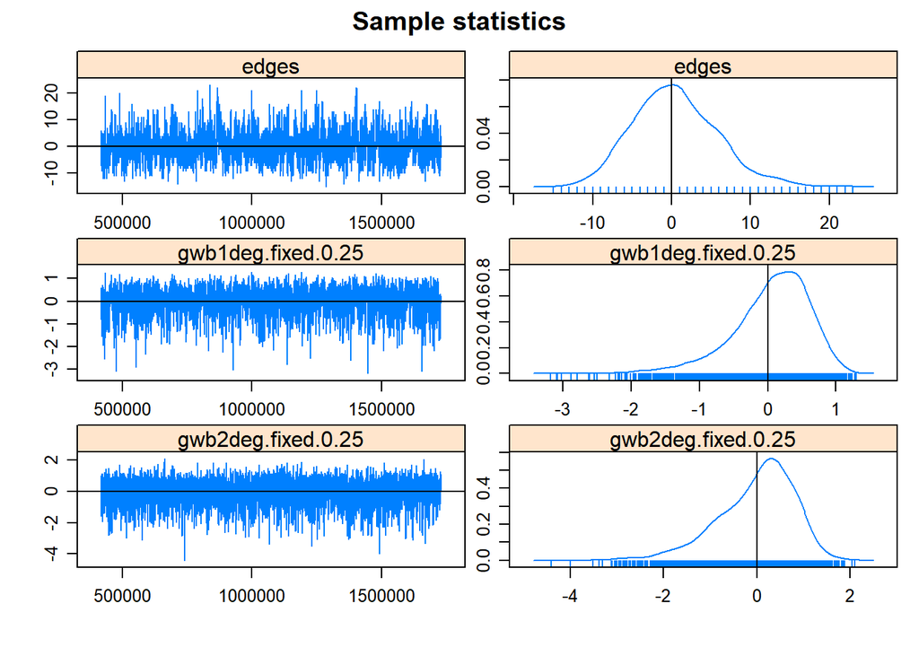

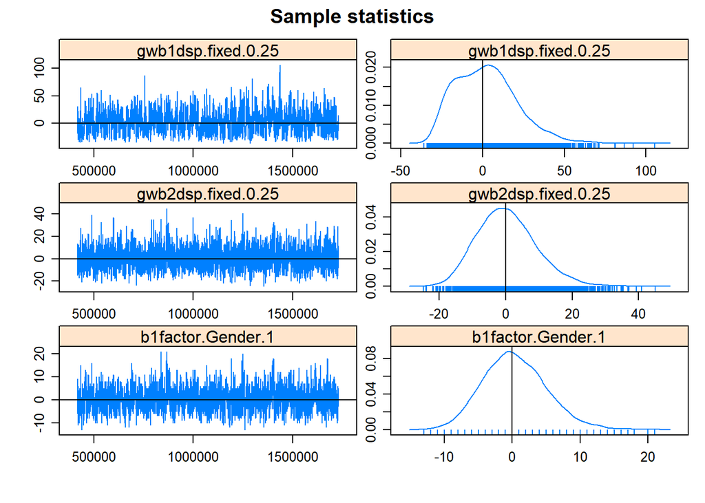

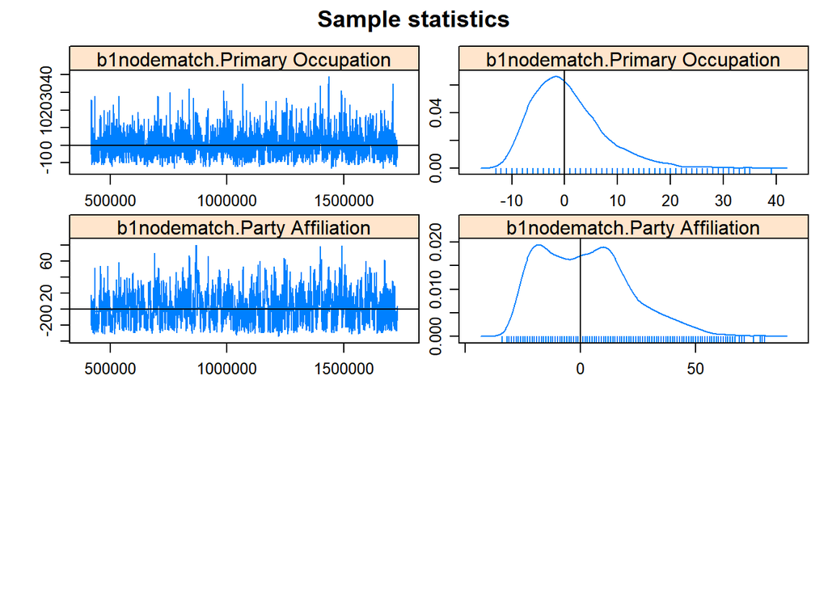

The diagrams indicate convergence.

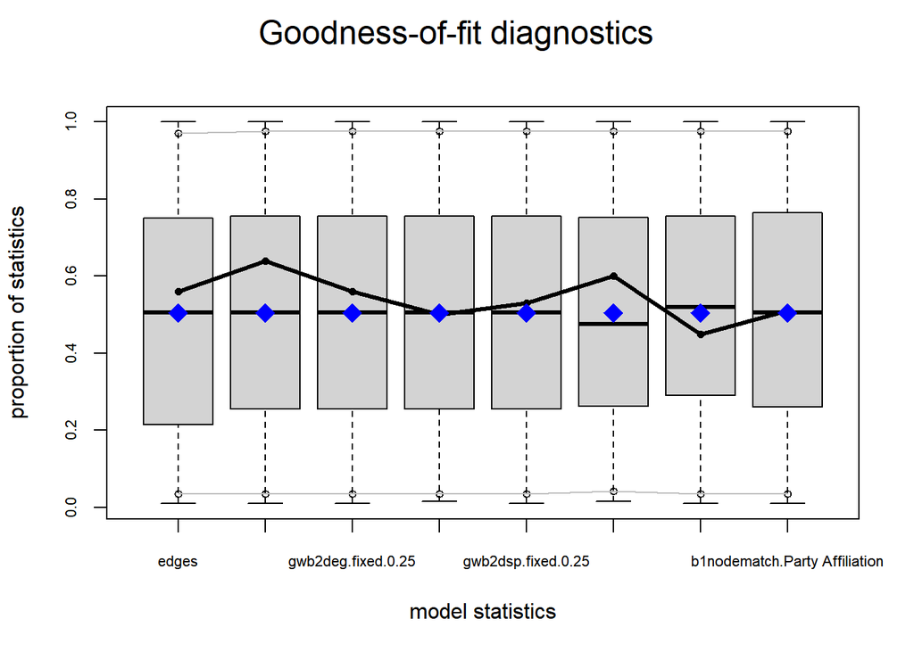

```r
elite_adv.gof <- gof(elite_adv, GOF = ~ model, plotlogodds=TRUE)
plot(elite_adv.gof)
```

# 6. Interpretation

Three effects, `edges`, `gwb2degree`, and `b1nodematch("Party Affiliation")` have statistically significant parameters with *p*-values less than 0.05.

1. The parameter for `edges` is equivalent to the intercept in log-linear models. The negativity of this parameter suggests that ties are observed less in the network than in local configurations (Amati, Lomi, and Mira 2018, 359). In short, ties are costly. This may derive from the US’s sheer size and decentralised nature.
2. The positive parameter of `gwb2degree` indicates the presence of a tendency for centralisation among think tanks. Indeed, it is highly likely that think tanks with more abundant financial resources hunt more celebrities to form a fancier board of directors.
3. The positive parameter for `b1nodematch("Party Affiliation")`, combined with the positive parameter of `gwb2degree`, illustrates that a strong homophily is present among the party members with think tanks as intermediaries. This explains the source of the centralisation tendency among the think tanks.
4. On the other hand, the fact that the parameter for `gwb2dsp` is not statistically significant suggests that think tanks are unlikely to form a cluster of elites. In other words, think tanks hunt celebrities, but the terrain of the US elites is not defined by think tanks. It is because (i) think tanks do not have power in themselves, and (ii) think tanks’ prestige depends on their intellectual output as well (see Smith et al. 2014). For instance, the Brookings Institution, a centrist think tank, invited a well-known conservative writer Robert Kagan as a senior fellow.
5. The statistical insignificance of the parameter for `b1factor.Gender.1` shows that we do not have good evidence to believe that gender contributes much to the variance in individual elites’ social behaviour. This may be explained by the result above that the elite network is driven primarily by organisational interaction. Thus, even dull Kissinger can attract as many allies as Gore does, provided he has a connection with the major political parties and a good public reputation.

# Bibliography

[1] Amati, Viviana, Alessandro Lomi, and Antonietta Mira. 2018. “Social Network Modeling.” *Annual Review of Statistics and Its Application* 5: 343-69.  
[2] Domhoff, G William. 2016. *Who Rules America?* Accessed on November 20, 2021. https://whorulesamerica.ucsc.edu.  
[3] Hollway, James. 2021. *Package ‘migraph’*. CRAN-R Project, October 30, 2021. https://cran.r-project.org/web/packages/migraph/migraph.pdf.  
[4] Smith, Jason M., Daniel S. Halgin, Virginie Lopez-Kidwell, Giuseppe Labianca, Daniel J. Brass, and Stephen P. Borgatti. 2014. “Power in Politically Charged Networks.” *Social Networks* 36: 162–76.  
[5] *Wikipedia*. 2021. “*Forbes* list of The World’s 100 Most Powerful Women.” Last modified December 12, 2021. https://en.wikipedia.org/w/index.php?title=Plagiarism&oldid=5139350.  
[6] Wang, Peng. 2013. “Exponential Random Graph Model Extensions: Models for Multiple Networks and Bipartite Networks.” In *Exponential Random Graph Models for Social Networks* edited by Dean Lusher, Johan Koskinen, and Garry Robins, 115-29. Cambridge, UK: Cambridge University Press.